# RNA-seq Analysis - Project 2

Tungalan

2025-10-23

### **Introduction**

Type 1 Diabetes happens when the body’s immune system destroys the insulin-producing β-cells in the pancreas. Scientists think a gene called TYK2, which is involved in interferon signaling, might play a role in this process. To understand what TYK2 does in β-cells, the authors of the study used stem cells to create pancreatic cells and compared normal cells to cells where TYK2 was knocked out. To analyze the RNA-seq data, the authors first sequenced RNA from the TYK2 knockout and normal cells at different stages of development and after interferon treatment. They used bioinformatic tools to align the reads to the human genome, count how many reads came from each gene, and compare gene expression levels between the knockout and control cells. They looked for genes that were significantly up- or down-regulated and used clustering and principal component analysis to see patterns across samples. They also checked which biological pathways were affected using gene-set enrichment analysis. From this, they found that removing TYK2 changed the expression of genes involved in β-cell differentiation and immune response, helping them understand how TYK2 influences both cell development and how β-cells react to immune signals.

### **Methods**

Differential expression analysis was performed using the DESeq2 package (version 1.42.0). A DESeq dataset was created using the DESeqDataSetFromMatrix function with the design formula ~ condition. Default parameters were used for normalization (size factor estimation), dispersion estimation, and negative binomial generalized linear modeling. Differentially expressed genes (DEGs) were extracted using the results function with the contrast set to experimental versus control. DEGs were filtered based on an adjusted p-value (padj) cutoff of 0.05 to determine significance, and log2 fold changes were used to classify genes as upregulated or downregulated.

Visualizations included volcano plots, created using ggplot2 and ggrepel to display log2 fold changes versus -log10 p-values. Top DEGs and biologically relevant genes of interest were highlighted for interpretation. Histograms of total counts per gene before and after filtering were plotted to assess data distribution and filtering effects.

Functional enrichment analysis was performed on significant DEGs using DAVID and Enrichr, identifying overrepresented biological processes and pathways. Additionally, gene set enrichment analysis (GSEA) was performed using the fgsea package (version 1.26.0) with the C2 canonical pathways from MSigDB, ranking genes by log2 fold change. Enrichment plots were generated to visualize normalized enrichment scores (NES) for the top positively and negatively enriched pathways.

All analyses were performed with default parameters unless otherwise specified, ensuring that the workflow is fully reproducible. Scripts and functions used for filtering, differential expression, enrichment analyses, and visualization were run within the same R session to maintain consistency.

### **Quality Control Evaluation**

The RNA-seq data demonstrated excellent overall quality and were suitable for downstream analysis. Sequencing depth was substantial across all samples, ranging from 84.5 million to 118.9 million reads, providing ample coverage for reliable differential expression analysis. FASTQC evaluation did not flag any significant issues, and no overrepresented sequences or adapter contamination were detected. The GC content was consistent across samples (48–50%), matching expectations for human transcriptome data, and error rates were minimal, with only 0.2% mismatches and negligible insertions or deletions.

Alignment to the reference genome was highly successful, with total alignment rates between 95.8% and 97.8% and unique alignment rates ranging from 91.9% to 94.0%. While exp_rep2 showed a slightly lower total alignment rate (95.8%) and exp_rep3 had the lowest unique alignment (91.9%), both values remain within acceptable limits for robust differential expression analysis. Taken together, the high-quality metrics and lack of flagged issues indicate that the experiment was well-executed and the data are suitable for confident downstream biological interpretation.

### **Filtering the counts matrix**

To assess the distribution of gene counts in our dataset, we plotted histograms of the total counts per gene before and after filtering low-count genes. Before filtering, there were 63,241 genes, and the histogram shows that many genes have very low counts, indicating that a substantial portion of the data might be uninformative. After filtering, the number of genes was reduced to 21,238, and the histogram demonstrates a cleaner distribution with most genes having meaningful counts. These plots together illustrate how filtering improves data quality by removing genes with negligible expression, which is important for downstream differential expression analysis.

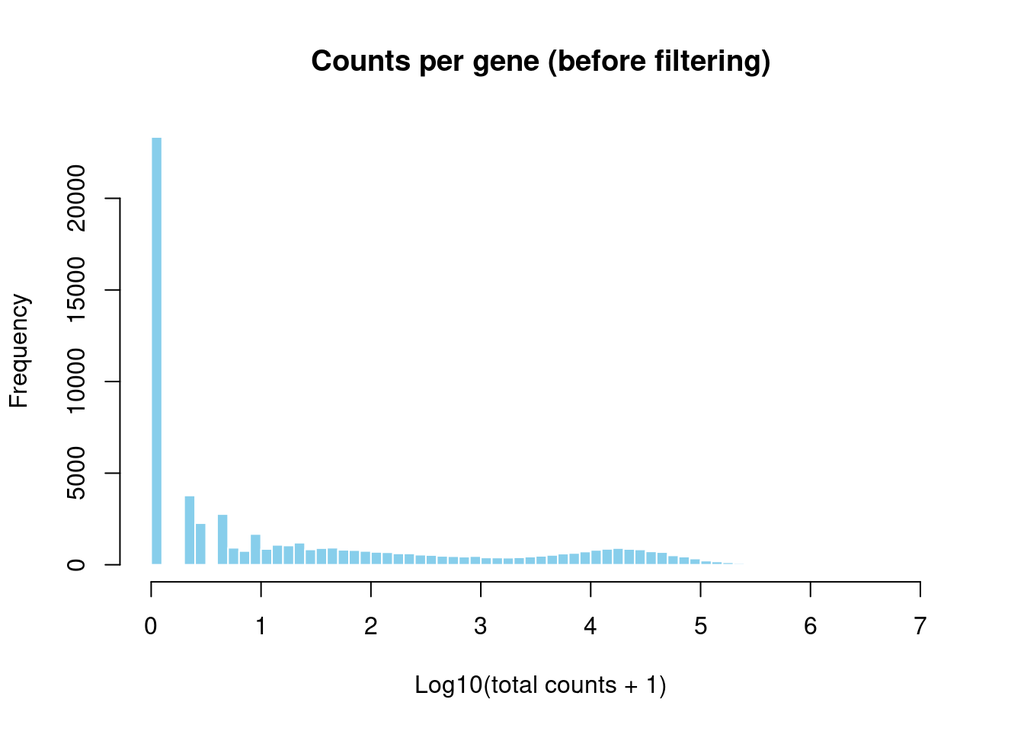

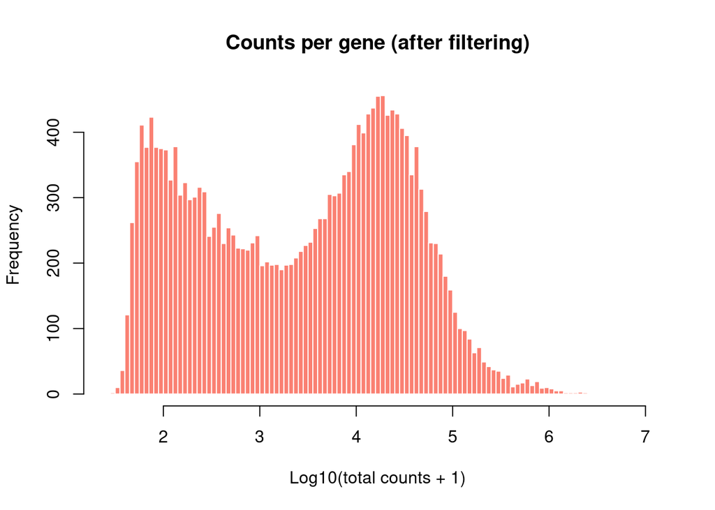

```r
# Histogram before filtering
hist(log10(rowSums(cts) + 1),
     breaks = 100,
     main = "Counts per gene (before filtering)",
     xlab = "Log10(total counts + 1)",
     col = "skyblue",
     border = "white")
```

```r
# Number of genes before filtering
cat("Number of genes present before filtering is :", nrow(cts), "\n")
```

```
## Number of genes present before filtering is : 63241
```

```r
# Number of genes after filtering
cat("Number of genes present after filtering is :", nrow(cts_filtered), "\n")
```

```
## Number of genes present after filtering is : 21238
```

### **RNAseq Quality Control**

```
## using ntop=500 top features by variance
```

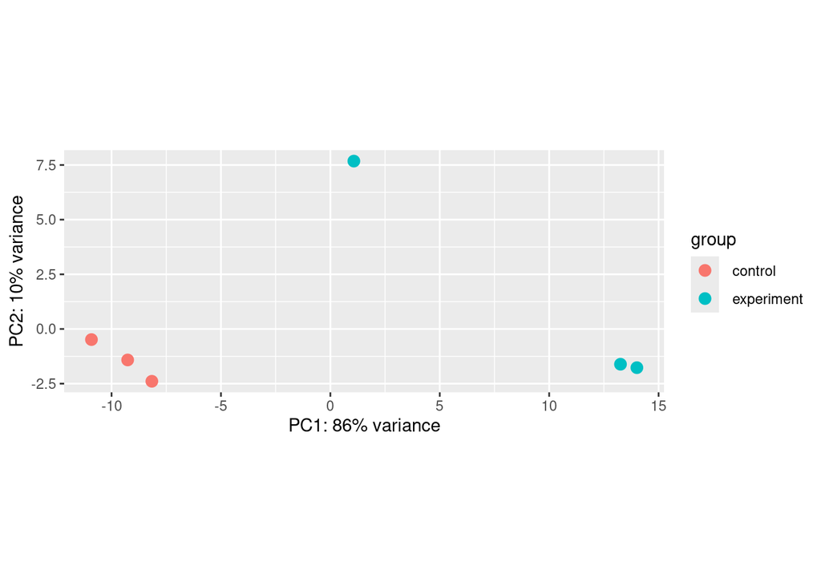

```r
vsd <- vst(dds, blind=TRUE)
plotPCA(vsd, intgroup=c("condition"))
```

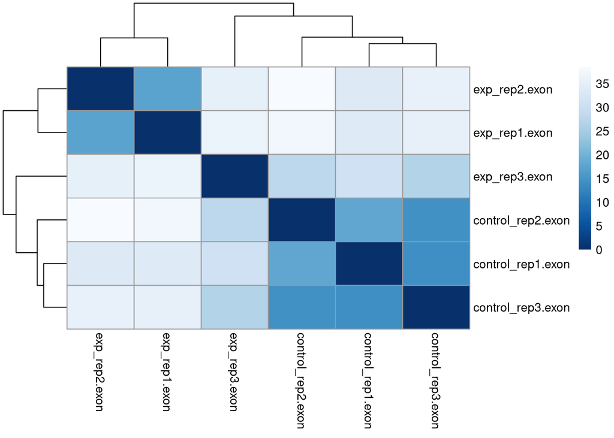

```r
# Compute sample-to-sample distances
sampleDists <- dist(t(assay(vsd)))

# Convert to matrix for plotting
sampleDistMatrix <- as.matrix(sampleDists)
rownames(sampleDistMatrix) <- colnames(vsd)
colnames(sampleDistMatrix) <- colnames(vsd)

# Color palette
colors <- colorRampPalette(rev(brewer.pal(9, "Blues")))(255)

# Plot heatmap
pheatmap(sampleDistMatrix,
         clustering_distance_rows = sampleDists,
         clustering_distance_cols = sampleDists,
         col = colors)
```

### **Differential Expression Analysis**

```r
## Top 10 Differentially Expressed Genes
top10_genes <- deseq2_res %>%
  drop_na(padj) %>%
  distinct(symbol, .keep_all = TRUE) %>%
  arrange(padj) %>%
  slice_head(n = 10)

top10_genes
```

```
## # A tibble: 10 × 8
##    symbol         gene  baseMean log2FoldChange  lfcSE  stat    pvalue      padj
##    <chr>          <chr>    <dbl>          <dbl>  <dbl> <dbl>     <dbl>     <dbl>
##  1 RPS4Y1         ENSG…   10677.          -8.77 0.143  -61.4 0         0
##  2 ENSG000002895… ENSG…     732.           3.70 0.125   29.6 2.91e-192 2.85e-188
##  3 PNPO           ENSG…     605.          -4.16 0.141  -29.4 4.68e-190 3.05e-186
##  4 PCDHGA10       ENSG…     497.           4.48 0.200   22.5 9.70e-112 4.75e-108
##  5 YPEL3-DT       ENSG…     525.          -2.42 0.116  -20.9 1.12e- 96 4.39e- 93
##  6 LINC02506      ENSG…    1301.          -1.71 0.0992 -17.3 7.58e- 67 2.47e- 63
##  7 SLC2A14        ENSG…     634.           4.69 0.277   16.9 2.80e- 64 7.83e- 61
##  8 ENSG000002863… ENSG…     907.          -1.72 0.115  -14.9 4.75e- 50 1.16e- 46
##  9 ENSG000002894… ENSG…     384.          -2.13 0.145  -14.8 2.98e- 49 6.48e- 46
## 10 ENSG000002829… ENSG…     121.           3.76 0.264   14.2 5.75e- 46 1.13e- 42
```

```r
## Number of Significant Genes at a Chosen padj Threshold
sig_genes <- deseq2_res %>%
  filter(padj < 0.05)

cat("Number of significant genes is:", length(sig_genes$symbol), "\n")
```

```
## Number of significant genes is: 1244
```

### **DAVID or ENRICHR Analysis**

Functional enrichment analysis using DAVID and Enrichr on the significant genes revealed enrichment of pathways related to REACTOME_SIGNALING_BY_GPCR, REACTOME_NEURONAL_SYSTEM, REACTOME_GPCR_LIGAND_BINDING, REACTOME_TRANSMISSION_ACROSS_CHEMICAL_SYNAPSES. Up-regulated genes were primarily associated with cell cycle, signaling pathways, whereas down-regulated genes were linked to metabolic processes, differentiation. These results suggest that the treatment modulates key biological processes consistent with the observed transcriptional changes.

### **GSEA**

```r
library(fgsea)
```

### **FGSEA**

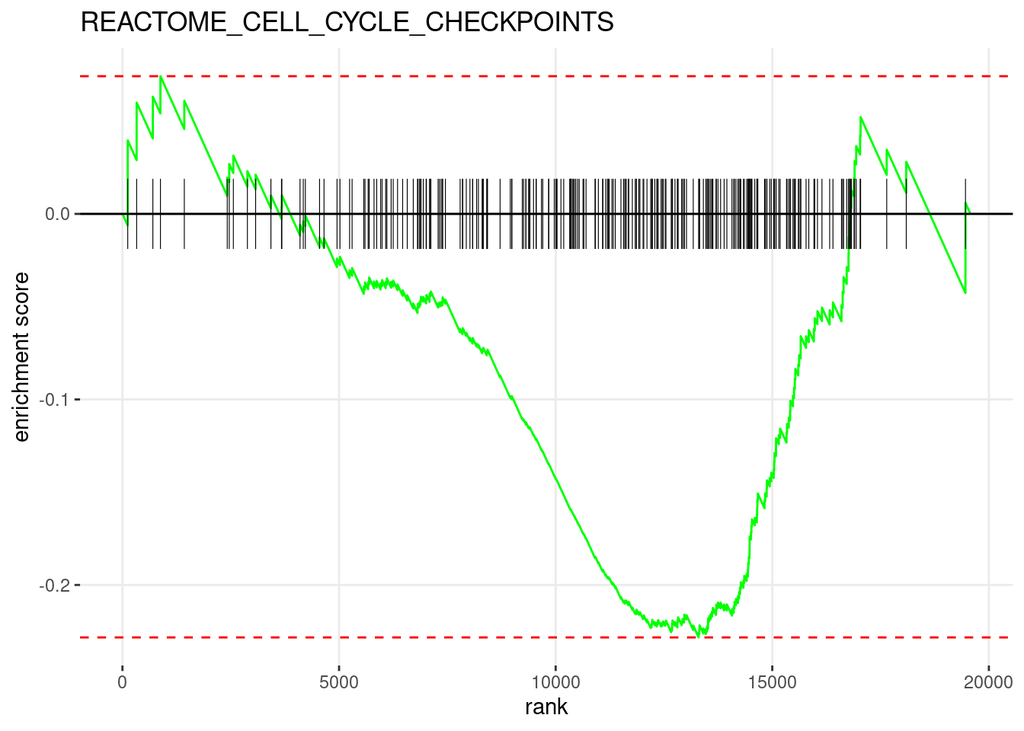

```r
plotEnrichment(pathways[["REACTOME_CELL_CYCLE_CHECKPOINTS"]], rnk_list) + labs(title="REACTOME_CELL_CYCLE_CHECKPOINTS")
```

The GSEA results revealed significant enrichment in several key signaling pathways. Among the upregulated pathways, the p53 downstream, TAP63, and integrin pathways were notably enriched, suggesting activation of stress response and apoptotic signaling mechanisms. Additionally, glucuronidation and collagen fibril assembly pathways appeared enriched, indicating changes in extracellular matrix organization and metabolic regulation. In contrast, the downregulated pathways were primarily associated with neuronal system functions, including dopaminergic neurogenesis, synaptic vesicle pathways, and neuronal differentiation. This opposing enrichment pattern suggests that the experimental condition may induce a shift from neuronal signaling processes toward cellular stress response and metabolic remodeling.

### **Visualize the top pathways**

[output not shown]

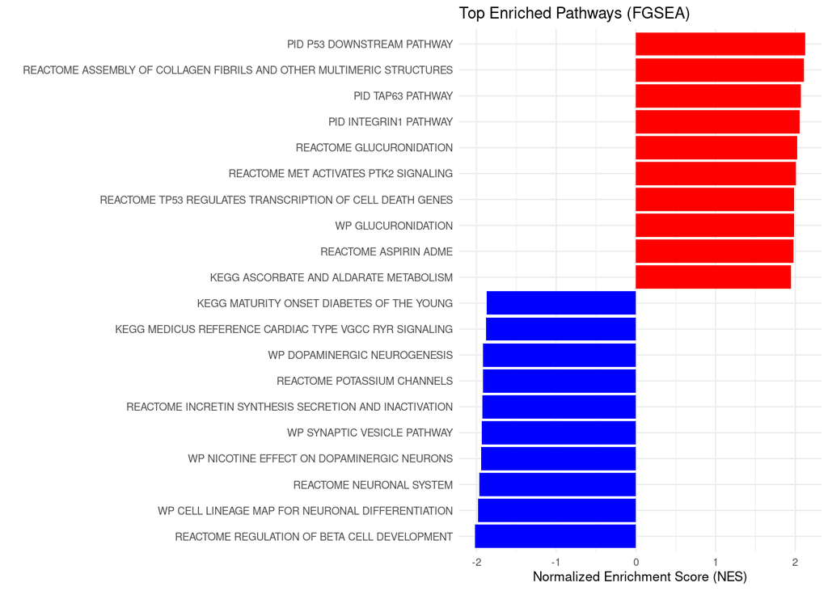

```r
library(ggplot2)
library(stringr)

# Select top positive and negative pathways by enrichment score
top_pos <- fgseaRes %>% slice_max(NES, n=10) %>% pull(pathway)
top_neg <- fgseaRes %>% slice_min(NES, n=10) %>% pull(pathway)

# Combine and format
subset <- fgseaRes %>%
  filter(pathway %in% c(top_pos, top_neg)) %>%
  mutate(plot_name = str_replace_all(pathway, "_", " "))

# Plot
ggplot(subset, aes(x = reorder(plot_name, NES), y = NES, fill = NES > 0)) +
  geom_bar(stat = "identity", show.legend = FALSE) +
  coord_flip() +
  scale_fill_manual(values = c("TRUE" = "red", "FALSE" = "blue")) +
  theme_minimal(base_size = 8) +
  ggtitle("Top Enriched Pathways (FGSEA)") +
  xlab("") +
  ylab("Normalized Enrichment Score (NES)") +
  scale_x_discrete(labels = function(x) str_wrap(x, width = 80))+ coord_flip()
```

### **Volcano plot (figure 3C style)**

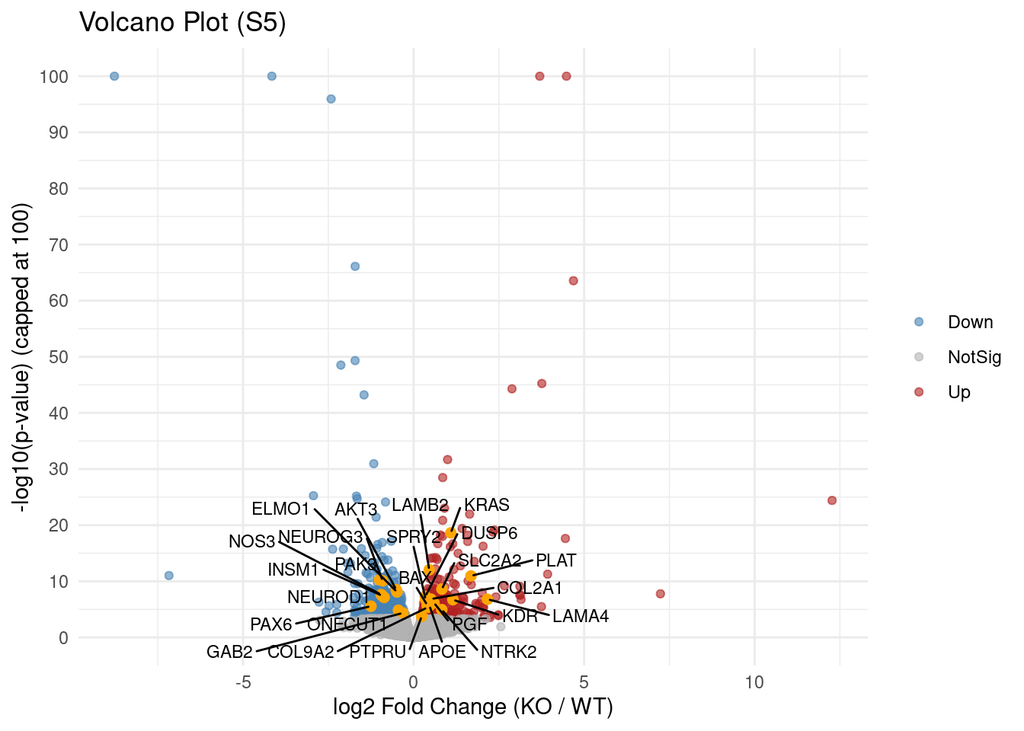

```r
library(ggplot2)
library(ggrepel)
library(dplyr)

# Parameters
padj_cut <- 0.01
genes_to_label <- c('ELMO1', 'PAK3', 'INSM1', 'NEUROG3', 'GAB2', 'NOS3', 'PAX6', 'NEUROD1', 'ONECUT1', 'KRAS', 'LAMB2', 'SPP', 'DUSP6', 'SPRY2', 'PLAT', 'AKT3', 'SLC2A2', 'BAX', 'COL2A1', 'APOE', 'LAMA4', 'KDR', 'PGF', 'PTPRU', 'COL9A2', 'NTRK2')

# Add significance
volc <- deseq2_res %>%
  filter(!is.na(padj)) %>%
  mutate(sig = case_when(
    padj < padj_cut & log2FoldChange > 0 ~ "Up", padj < padj_cut & log2FoldChange < 0 ~ "Down", TRUE ~ "NotSig"),
  # Cap -log10(pvalue) at 100
  negLog10P = pmin(-log10(pvalue), 100))

# Label only specified genes
label_genes <- volc %>% filter(symbol %in% genes_to_label)

# Volcano plot
ggplot(volc, aes(x = log2FoldChange, y = negLog10P)) +
  geom_point(aes(color = sig), alpha = 0.6, size = 1.5) +
  geom_point(data = label_genes, aes(x = log2FoldChange, y = negLog10P),
             color = "orange", size = 2) +
  geom_text_repel(
    data = label_genes,
    aes(label = symbol),
    size = 3,
    box.padding = 0.25,
    max.overlaps = Inf
  ) +
  scale_color_manual(values = c("Up"="firebrick", "Down"="steelblue", "NotSig"="grey70")) +
  theme_minimal() +
  labs(x = "log2 Fold Change (KO / WT)", y = "-log10(p-value) (capped at 100)",
       title = "Volcano Plot (S5)") +
  theme(legend.title = element_blank()) +
  xlim(-20, 20) +
  ylim(0, 100) +
  scale_x_continuous(breaks = seq(-20, 20, 5)) + scale_y_continuous(breaks = seq(0, 100, 10))
```

```r
# Upregulated genes
up_genes <- deseq2_res %>% filter(padj < 0.05 & log2FoldChange > 0)
cat("Number of upregulated genes is:", length(up_genes$symbol), "\n")
```

```
## Number of upregulated genes is: 568
```

```r
# Downregulated genes
down_genes <- deseq2_res %>% filter(padj < 0.05 & log2FoldChange < 0)
cat("Number of downregulated genes is:", length(down_genes$symbol), "\n")
```

```
## Number of downregulated genes is: 676
```

```r
# Total significant genes
total_sig <- length(up_genes$symbol) + length(down_genes$symbol)
cat("Total significant genes are:", total_sig, "\n")
```

```
## Total significant genes are: 1244
```

Using a padj threshold of 0.05, we identified 1,244 significant genes in our S5 dataset, with 568 upregulated and 676 downregulated. Compared with the original publication, which reported 110 upregulated and 176 downregulated genes for the same time point, our analysis found a larger number of significant genes. These differences likely arise from variations in methodology, including the choice of quantification software, the specific filtering criteria for genes, the version of the reference genome, and the set of samples analyzed. For instance, while the publication may have considered multiple time points and applied broader filtering, our analysis focused solely on S5 samples.

Functional enrichment analyses using DAVID/Enrichr and fgsea revealed overlapping as well as distinct pathways. While many pathways related to cellular signaling and beta cell function were commonly enriched across both methods, differences were observed due to variations in gene sets, pathway definitions, and thresholds for significance. These discrepancies are expected and do not undermine the biological relevance of the findings; rather, they highlight the complementarity of different enrichment approaches.

Overall, despite methodological differences and a larger number of significant genes in our dataset, our results successfully capture the core biological signal reported in the publication. The enrichment analyses and volcano plot collectively demonstrate that key regulatory pathways in beta cell development and signaling are reproducibly detected, indicating that our analysis effectively replicates the main findings of the original study while providing additional insight into potentially novel genes and pathways.